# Week 4 - Paleoecological Reconstructions and Proxy Development II: From Distributions to Sampling

C.A. Kiahtipes

9/14/2023

## Week 4: From Distributions to Sampling

### 1. Introduction

As we think about time-averaging and taphonomic bias in the sedimentary record, we can use R tools to visualize these concepts. We talked last week about basic univariate statistics like means, medians, and modes. We familiarized ourselves a bit more with apply(), table(), and summary() to derive insights into the distribution of our data. We also introduced variance and standard deviations.

This week, we develop our understanding of variance, deviation, and standard deviations a bit more and will learn how these descriptions of variance can help us work through some examples of how taphonomy can transform fossil communities, and how we might deal with it. We do this because the sedimentary record contains fossils that are biased by, first, biological production and, second, differential preservation. As we try to bridge ecological and paleoecoloical scales, we must translate fossil counts into landscape distributions, population estimates, or even past environmental conditions. We can understand biological production and sedimentation more clearly as sampling processes. This means that past biological populations can *never* be compared with our estimates and that we are always dealing with a biased sampling of past communities, to some degree.

### 2. Describing Differences in Observation Variables

Standard deviations help us characterize variation in either a sample or a population of things. It is derived from some related values that are worth knowing.

Methods for describing variance.

- Mean absolute deviation - sum of all deviations from mean divided by number of observations. Function call = mad()
- Variance - sum of the squared deviations from mean divided by the number of observations. Function call = var()
- Sample Variance - identical to variance, but number of observations is corrected as (n -1). Functioncall = var()

```r
mad(fake_core$Cyperaceae.undiff.)
```

```
## [1] 13.3434
```

```r
mad_cyp = sum( abs(fake_core$Cyperaceae.undiff. - median(fake_core$Cyperaceae.undiff.) ) ) / length(fake_core$Cyperaceae.undiff.)

mad_cyp
```

```
## [1] 8.86
```

Above, we get some different results between R and a manual calculation because the mad() function uses a constant to adjust for “asmptotically normal consistency” (see help(mad)). Notice first that we can use mean or median to as a basis for absolute deviation for our vectors. This can be set with the “center =” and “constant =” arguments in mad() or within our manual calculation, we take the mean value of the absolute differences between the individual observations and their mean. This looks different from the formula above because I’ve subsumed the “sum()” and “/length(x)” functions by calling the entire calculation under “mean()”. If we calculate the value manually using the median (second half of code below), we get the same value as the “mad()” function, using a constant of 1.

```r
mad(fake_core$Cyperaceae.undiff., center = mean(fake_core$Cyperaceae.undiff.), constant = 1)
```

```
## [1] 8.74
```

```r
mad_cyp = mean(abs(fake_core$Cyperaceae.undiff. - mean(fake_core$Cyperaceae.undiff.)))

mad_cyp
```

```
## [1] 8.8652
```

```r
#Now we calculate the median average deviation.

mad_cyp = median(abs(fake_core$Cyperaceae.undiff - median(fake_core$Cyperaceae.undiff.)))

mad_cyp
```

```
## [1] 9
```

```r
mad(fake_core$Cyperaceae.undiff., constant = 1)
```

```
## [1] 9
```

Here we are working with *deviation* from the mean or median. This is a logical enough way to express deviation in a set of numbers, but its applications and interpretation are limited (ex: how easy is it to compare between variables?). However, it does set the foundation of how we calculate *variance*, which is the sum of the squared deviations from the mean divided by the number of observations. For samples, we calculate the latter as the number of observations less one (N - 1). Base R has a function for variance “var()”, but we can also calculate it manually.

```r
var(fake_core$Cyperaceae.undiff.)
```

```
## [1] 105.164
```

```r
var_cyp = mean((fake_core$Cyperaceae.undiff. - mean(fake_core$Cyperaceae.undiff.))^2)

#Perhaps R calculates variance for a sample and not a population...

var_cyp = sum((fake_core$Cyperaceae.undiff. - mean(fake_core$Cyperaceae.undiff.))^2)/
  (length(fake_core$Cyperaceae.undiff.)-1) #Note that we're taking N - 1 here.

var(fake_core$Cyperaceae.undiff.)
```

```
## [1] 105.164
```

```r
var_cyp
```

```
## [1] 105.164
```

In this case, we’ve finally gotten identical values when compared with the base R function. But what does variance mean and how do we interpret it? R lets us generate a lot of fake and specifically structured data. Let’s look at some general features of variance by looking at systematically modified input.

```r
my_df = sapply(1:10, function(x){ #Using function to create progressively larger runs of numbers that are equally spaced.
    seq(x, x*100, x)
})

apply(my_df, 2, var)
```

```
##  [1]   841.6667  3366.6667  7575.0000 13466.6667 21041.6667 30300.0000
##  [7] 41241.6667 53866.6667 68175.0000 84166.6667
```

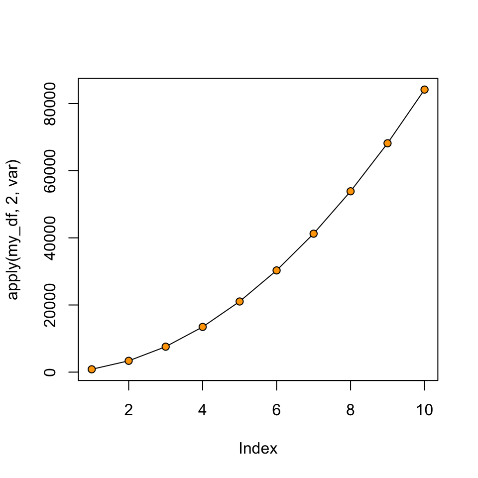

```r
plot(apply(my_df, 2, var), type = "o", pch = 21, bg = "orange")
```

Naturally, as the range of values gets larger the variance goes up. While the range grows by 100s, the variance does not grow linearly. Let’s look at a longer range of numbers and see how variance and the overall spread of the data interact.

```r
my_df = sapply(1:100, function(x){ #Using function to create progressively larger runs of numbers that are equally spaced.
    seq(x, x*100, x)
})

apply(my_df, 2, var)
```

```
##   [1]     841.6667    3366.6667    7575.0000   13466.6667   21041.6667
##   [6]   30300.0000   41241.6667   53866.6667   68175.0000   84166.6667
##  [11]  101841.6667  121200.0000  142241.6667  164966.6667  189375.0000
##  [16]  215466.6667  243241.6667  272700.0000  303841.6667  336666.6667
##  [21]  371175.0000  407366.6667  445241.6667  484800.0000  526041.6667
##  [26]  568966.6667  613575.0000  659866.6667  707841.6667  757500.0000
##  [31]  808841.6667  861866.6667  916575.0000  972966.6667 1031041.6667
##  [36] 1090800.0000 1152241.6667 1215366.6667 1280175.0000 1346666.6667
##  [41] 1414841.6667 1484700.0000 1556241.6667 1629466.6667 1704375.0000
##  [46] 1780966.6667 1859241.6667 1939200.0000 2020841.6667 2104166.6667
##  [51] 2189175.0000 2275866.6667 2364241.6667 2454300.0000 2546041.6667
##  [56] 2639466.6667 2734575.0000 2831366.6667 2929841.6667 3030000.0000
##  [61] 3131841.6667 3235366.6667 3340575.0000 3447466.6667 3556041.6667
##  [66] 3666300.0000 3778241.6667 3891866.6667 4007175.0000 4124166.6667
##  [71] 4242841.6667 4363200.0000 4485241.6667 4608966.6667 4734375.0000
##  [76] 4861466.6667 4990241.6667 5120700.0000 5252841.6667 5386666.6667
##  [81] 5522175.0000 5659366.6667 5798241.6667 5938800.0000 6081041.6667
##  [86] 6224966.6667 6370575.0000 6517866.6667 6666841.6667 6817500.0000
##  [91] 6969841.6667 7123866.6667 7279575.0000 7436966.6667 7596041.6667
##  [96] 7756800.0000 7919241.6667 8083366.6667 8249175.0000 8416666.6667
```

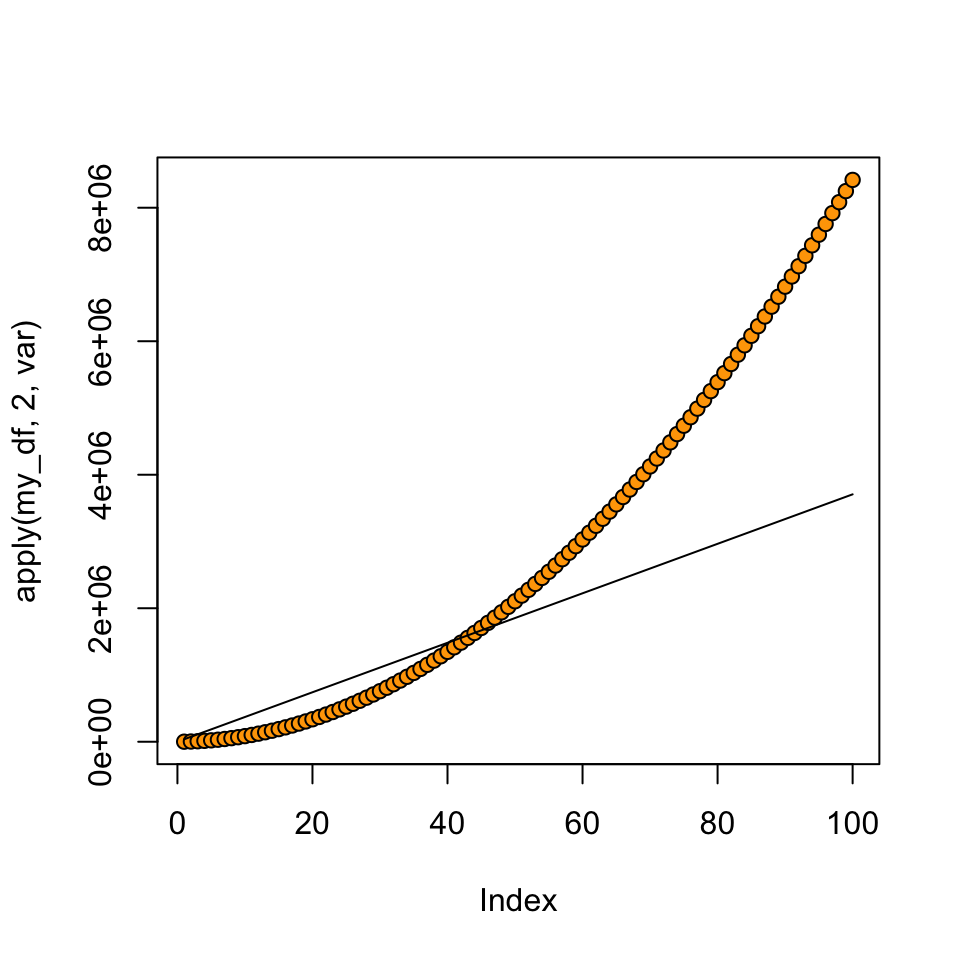

```r
plot(apply(my_df, 2, var),
     type = "o",
     pch = 21,
     bg = "orange")

lines(apply(my_df, 2, mad)*1000) #Here we're adding the MAD values for the same dataset, multiplied by 1000 to make them visible.
```

### 3. Using Systematic Variation to Test Parameters

We can learn a bit more by creating longer lists of repeating numbers, which will show us some of the impacts of sample size. Below, we make a short list of numbers with a mean and median of 9, then we repeat that list of numbers 100 times, taking the variance and median absolute deviation. The code below gives us three plots: one showing variance/MAD across the 100 repetitions of the number string; one showing a histogram of this data, and another showing frequency distributions as displayed using a combination of “plot()” and “table()” methods.

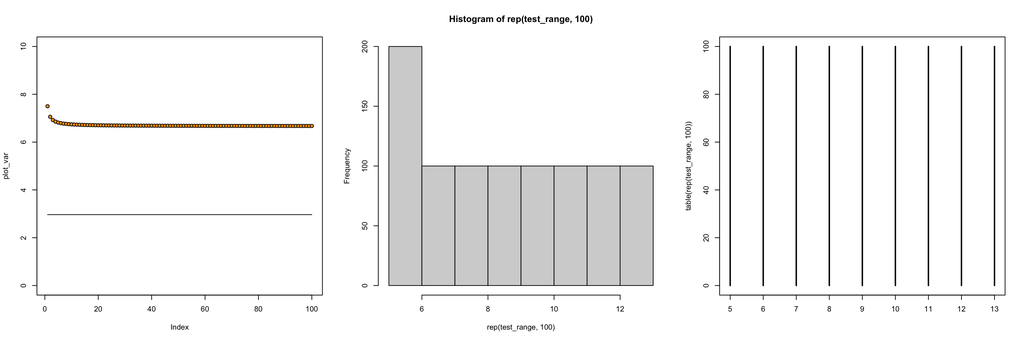

```r
test_range = c(5:13)

plot_var = sapply(1:100, function(x){
  var(rep(test_range, x))
})

plot_mad = sapply(1:100, function(x){
  mad(rep(test_range, x))
})

par(mfrow = c(1, 3))

plot(plot_var, ylim = c(0,10), pch = 21, bg = "orange")

lines(plot_mad)

hist(rep(test_range, 100))

plot(table(rep(test_range,100)))
```

```r
par(mfrow = c(1, 1))
```

Regarding variance, we see a minor impact of the total sample size on our measurement of variance, but it quickly approaches an asymptote after being doubled three or four times. The distribution of this data is even and we see that increasing the number of observations (so long as they’re the same numbers) does not impact our estimation of the mean or median. Will this hold for a set of numbers where the frequency distribution isn’t even?

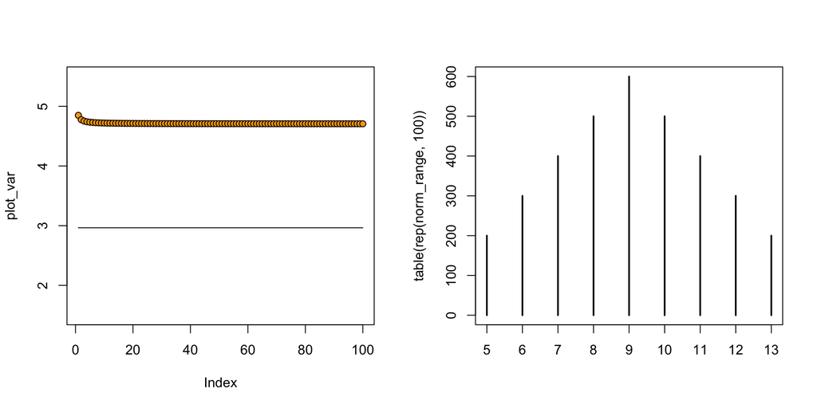

```r
norm_range = #Using <shift+enter>, we can already make a visualization of the counts...
    c(5, 5,
      6, 6, 6,
      7, 7, 7, 7,
      8, 8, 8, 8, 8,
      9, 9, 9, 9, 9, 9,
      10, 10, 10, 10, 10,
      11, 11, 11, 11,
      12, 12, 12,
      13, 13)

plot_var = sapply(1:100, function(x){
  var(rep(norm_range, x))
})

plot_mad = sapply(1:100, function(x){
  mad(rep(norm_range, x))
})

par(mfrow = c(1, 2))

plot(plot_var, ylim = c(floor(min(plot_mad)) - 0.5, ceiling(max(plot_var)) +0.5), pch = 21, bg = "orange")

lines(plot_mad)

plot(table(rep(norm_range,100)))
```

```r
par(mfrow = c(1, 1))
```

Let’s try this with a v-shaped distribution.

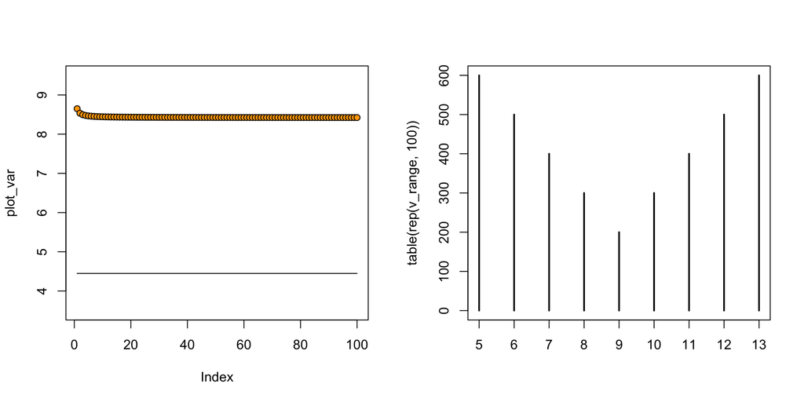

```r
v_range = c(
      5, 5, 5, 5, 5, 5,
      6, 6, 6, 6, 6,
      7, 7, 7, 7,
      8, 8, 8,
      9, 9,
      10, 10, 10,
      11, 11, 11, 11,
      12, 12, 12, 12, 12,
      13, 13, 13, 13, 13, 13)

plot_var = sapply(1:100, function(x){
  var(rep(v_range, x))
})

plot_mad = sapply(1:100, function(x){
  mad(rep(v_range, x))
})

par(mfrow = c(1, 2))

plot(plot_var, ylim = c(floor(min(plot_mad)) - 0.5, ceiling(max(plot_var)) +0.5), pch = 21, bg = "orange")

lines(plot_mad)

plot(table(rep(v_range,100)))
```

```r
par(mfrow = c(1, 1))
```

The replication structure we’re using here will serve us in the future. Let’s codify the repetitions and plotting into a function to save us all this copy-pasting.

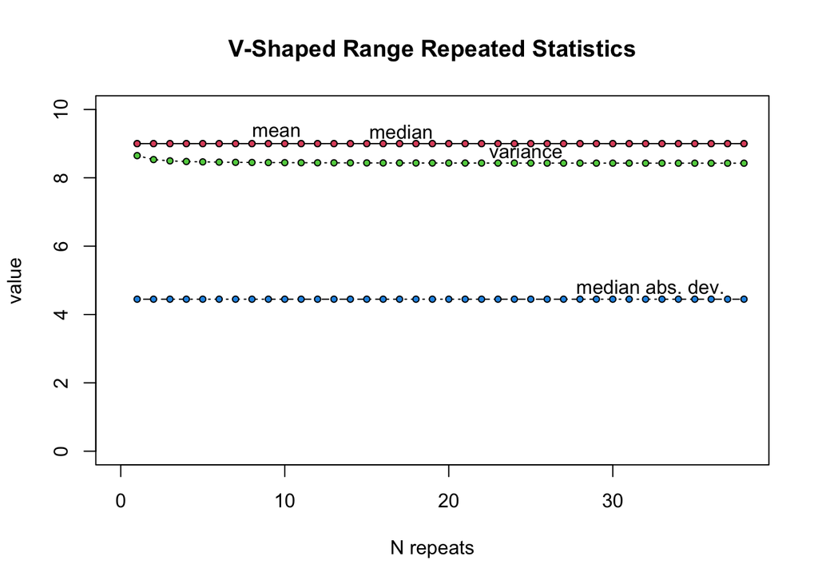

```r
stat_lines = function(x,#Creating a function called "stat_lines" it expects some vector of data "x" and the following arguments
                      times = length(x), #Setting this to "length(x)" by default, so calling this won't always be necessary. But we can add our own numbers!
                      title = NA){ #Setting up a title object, defaulting to NA

  plot_u = sapply(1:times, function(y){ #Here's that fast custom function that creates means for the repeated set of numbers.
    mean(rep(x, y))
  })

  plot_med = sapply(1:times, function(y){ #Same, but for the median.
    median(rep(x, y))
  })

  plot_var = sapply(1:times, function(y){ #Same, but for variance.
    var(rep(x, y))
  })

  plot_mad = sapply(1:times, function(y){ #Same, but for median absolute deviation
    mad(rep(x, y))
  })

  stat_labels = c("mean", "median", "variance", "median abs. dev.")

  plot_stats = data.frame(plot_u, plot_med, plot_var, plot_mad)

  plot(0, 0, xlim = c(0, times), ylim = c(0, max(plot_stats)+1), pch = NA, xlab = "N repeats", ylab = "value", main =paste0(title," Repeated Statistics"))

  for(i in 1:ncol(plot_stats)){
    points(plot_stats[, i], type = "o", pch = 21, lty = i, bg = i, cex = 0.7)
    text(times*0.05+(i*(0.2*times)), min(plot_stats[, i])+(0.04*max(plot_stats)), labels = stat_labels[i])
  }

}

stat_lines(v_range, title = "V-Shaped Range")
```

This makes plotting this much easier, allowing us to make some quick comparisons between our two small datasets, which we are making much larger using the “rep()” function.

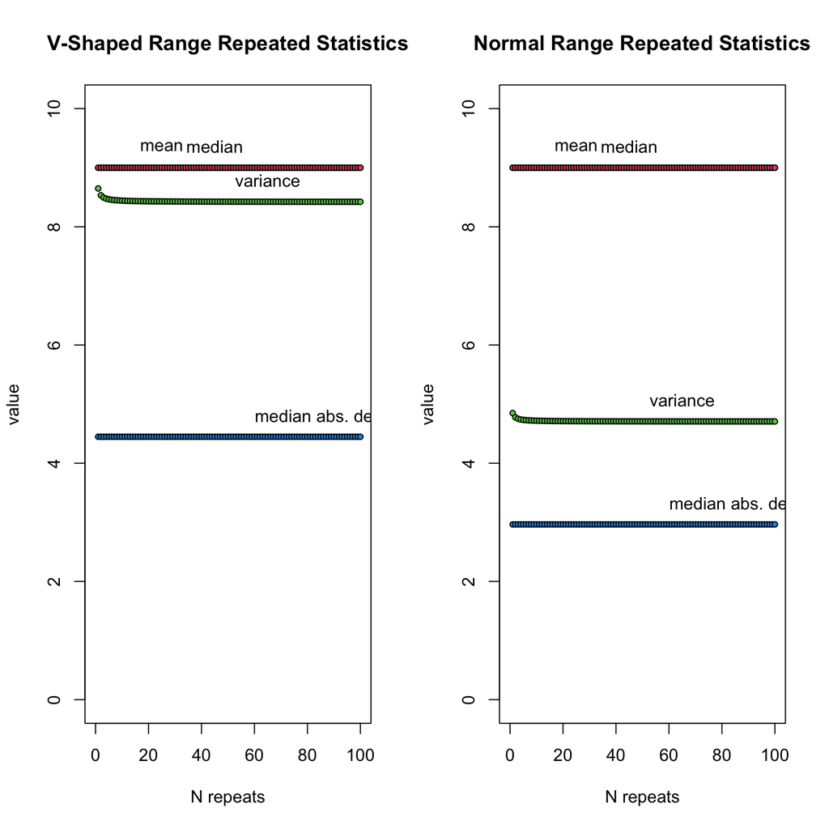

```r
par(mfrow = c(1,2))

stat_lines(v_range, title = "V-Shaped Range", times = 100)

stat_lines(norm_range, title = "Normal Range", times = 100)
```

```r
par(mfrow = c(1,1))
```

We can apply this same approach to some of the fake core data.

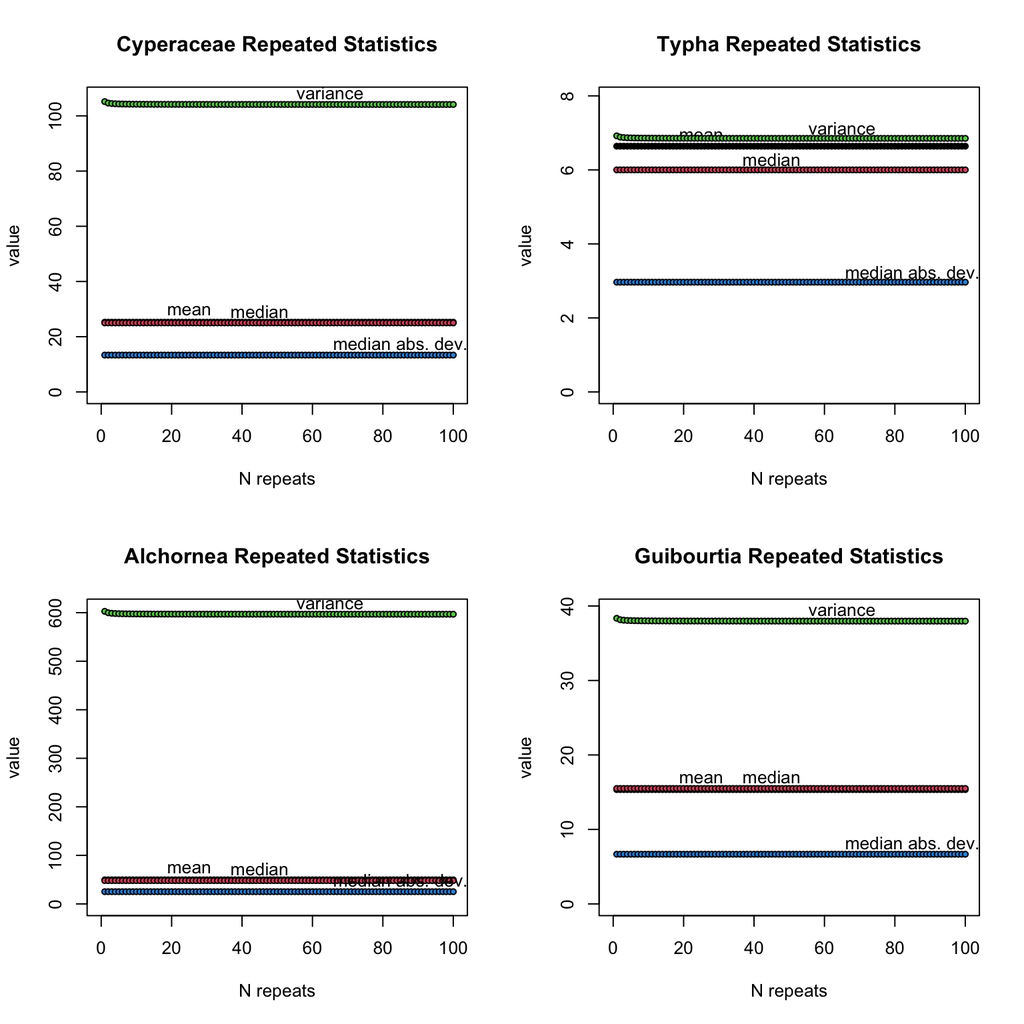

```r
par(mfrow = c(2,2))

stat_lines(fake_core$Cyperaceae.undiff., title = "Cyperaceae")
stat_lines(fake_core$Typha, title = "Typha")
stat_lines(fake_core$Alchornea, title = "Alchornea")
stat_lines(fake_core$Guibourtia.demeusei, title = "Guibourtia")
```

```r
par(mfrow = c(1,1))
```

What all of this demonstrates is that:

### 4. At Last, Standard Deviations

Thus, to standardize our estimate of deviation, we take the square root of variance.

```r
sd(fake_core$Cyperaceae.undiff.)
```

```
## [1] 10.25495
```

```r
sd_cyp = sqrt(var(fake_core$Cyperaceae.undiff.))

sd_cyp
```

```
## [1] 10.25495
```

Let’s see how it performs when we systematically manipulate the data again.

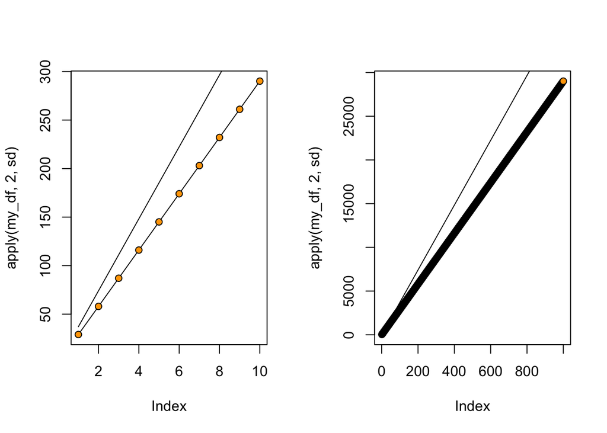

```r
par(mfrow = c(1, 2))

my_df = sapply(1:10, function(x){ #Using function to create progressively larger runs of numbers that are equally spaced.
    seq(x, x*100, x)
})

#apply(my_df, 2, sd)

plot(apply(my_df, 2, sd), type = "o", pch = 21, bg = "orange")
lines(apply(my_df, 2, mad))

my_df = sapply(1:1000, function(x){
  seq(x, x*100, x)
})

plot(apply(my_df, 2, sd), type = "o", pch = 21, bg = "orange")
lines(apply(my_df, 2, mad))
```

```r
par(mfrow = c(1, 1))
```

Let’s add standard deviations to our basic plots and remove the variance.

```r
stat_lines = function(x,#Creating a function called "stat_lines" it expects some vector of data "x" and the following arguments
                      times = length(x), #Setting this to "length(x)" by default, so calling this won't always be necessary. But we can add our own numbers!
                      title = NA){ #Setting up a title object, defaulting to NA

  plot_u = sapply(1:times, function(y){ #Here's that fast custom function that creates means for the repeated set of numbers.
    mean(rep(x, y))
  })

  plot_med = sapply(1:times, function(y){ #Same, but for the median.
    median(rep(x, y))
  })

  #plot_var = sapply(1:times, function(y){ #Same, but for variance. #We can keep our code and just hash this out.
  #  var(rep(x, y))
  #})

  plot_mad = sapply(1:times, function(y){ #Same, but for median absolute deviation
    mad(rep(x, y))
  })

  plot_sd = sapply(1:times, function(y){
    sd(rep(x, y))
  })

  stat_labels = c("mean", "median", "median abs. dev.", "SD") #Because we automate everything below, all we have to do is modify the names.

  plot_stats = data.frame(plot_u, plot_med, plot_mad, plot_sd) #We're using the plot_stats dataframe below, so we modify the entry here.

  plot(0, 0, xlim = c(0, times), ylim = c(0, max(plot_stats)+1), pch = NA, xlab = "N repeats", ylab = "value", main =paste0(title," Repeated Statistics"))

  for(i in 1:ncol(plot_stats)){
    points(plot_stats[, i], type = "o", pch = 21, lty = i, bg = i, cex = 0.7)
    text((times/ncol(plot_stats)*i), min(plot_stats[, i])+(0.04*max(plot_stats)), labels = stat_labels[i]) #Changing text plotting to fit new variable.
  }

}
```

Let’s plot our selected taxa again.

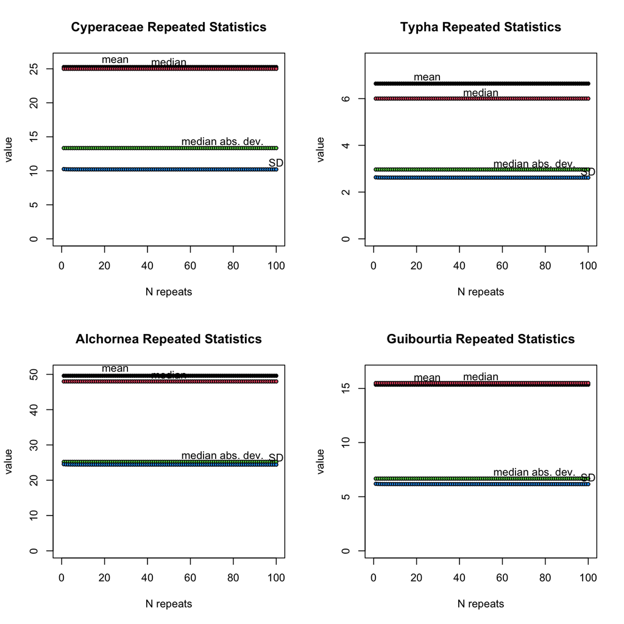

```r
par(mfrow = c(2,2))

stat_lines(fake_core$Cyperaceae.undiff., title = "Cyperaceae")
stat_lines(fake_core$Typha, title = "Typha")
stat_lines(fake_core$Alchornea, title = "Alchornea")
stat_lines(fake_core$Guibourtia.demeusei, title = "Guibourtia")
```

```r
par(mfrow = c(1,1))
```

At last, we see that the SD is slightly more conservative than median absolute deviations. Because we’ve taken variance, which is sensitive to total dispersion, and standardized it by differences from the mean we end up with a value that is easier to interpret. This is why most of us understand some basic principles of standard deviations without knowing why this value has these characteristics. Thus, standard deviations are the typical distance from the mean that characterizes a set of values.

### 5. Back to Frequency Distributions, Sampling Basics

Armed with our newfound knowledge of variance, we can make good use of some powerful R functions:

- rnorm() - generates a set of numbers based on a normal distribution.
- sample() - randomly samples from a given input.

We can also verify this with some population thinking using the function “rnorm()” which lets us create a normally-distributed sample using arguments for the number of random numbers, mean, and standard deviation.

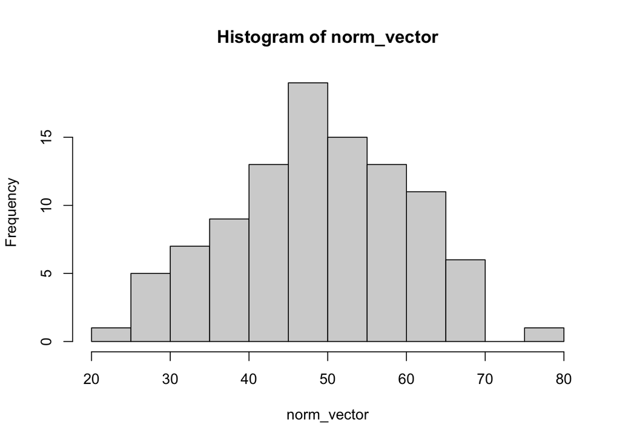

```r
norm_vector = rnorm(n = 100, mean = 50, sd = 10)

hist(norm_vector)
```

Let’s see how this distribution changes when we systematically increase the sample size.

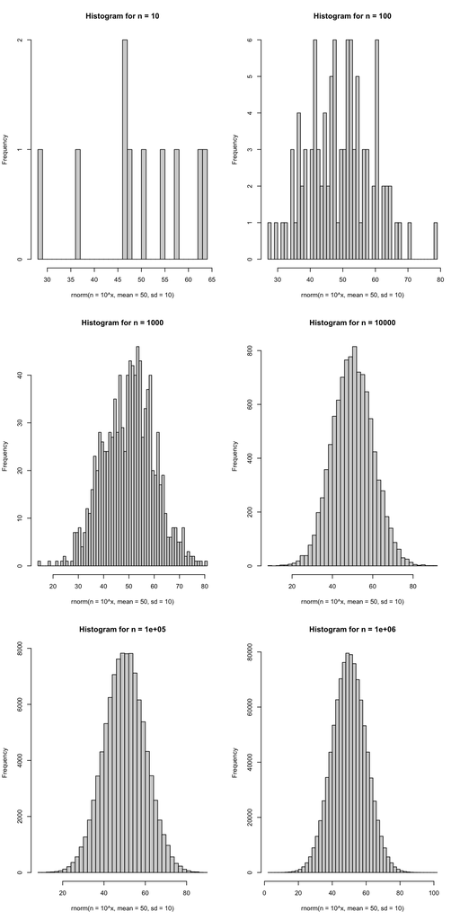

```r
par(mfrow = c(3,2)) #We're making six plots

invisible(sapply(1:6, function(x){ #Using a custom function six times
  hist(rnorm(n = 10^x, #Call histogram for a normally distributed set of random numbers, increasing by orders of magnitude (10^i)
             mean = 50, #Set the mean of the random values
             sd = 10), #Set the standard deviation
       breaks = 50, #Breaks for histogram
       main = paste0("Histogram for n = ", 10^x)) #Title for plots
}))
```

```r
par(mfrow = c(1,1))
```

R lets us create data using rbeta(), which generates some skewed data. There’s two arguments for shape (“shape1” and “shape2”). As the two numbers get closer together, the distribution becomes more normal.

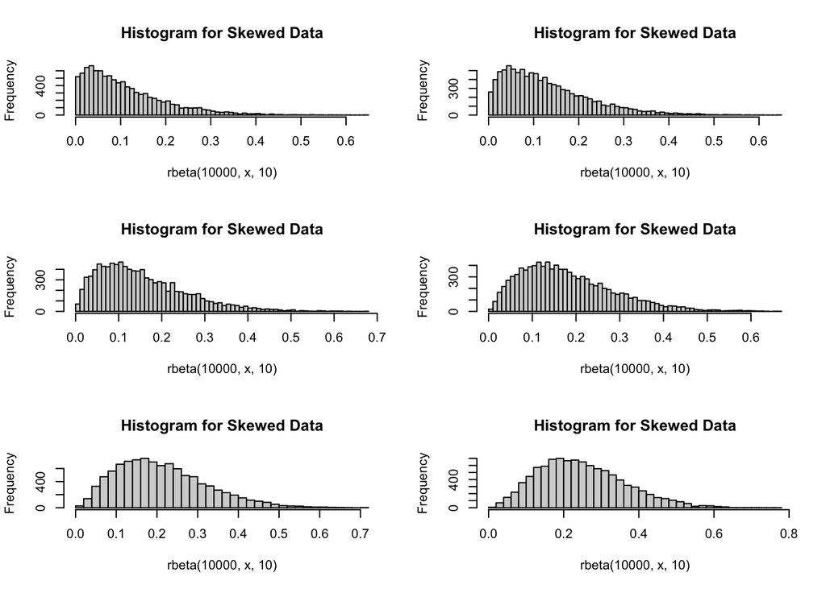

```
##          [,1]                  [,2]                  [,3]
## breaks   numeric,66            numeric,66            numeric,69
## counts   integer,65            integer,65            integer,68
## density  numeric,65            numeric,65            numeric,68
## mids     numeric,65            numeric,65            numeric,68
## xname    "rbeta(10000, x, 10)" "rbeta(10000, x, 10)" "rbeta(10000, x, 10)"
## equidist TRUE                  TRUE                  TRUE
##          [,4]                  [,5]                  [,6]
## breaks   numeric,68            numeric,37            numeric,40
## counts   integer,67            integer,36            integer,39
## density  numeric,67            numeric,36            numeric,39
## mids     numeric,67            numeric,36            numeric,39
## xname    "rbeta(10000, x, 10)" "rbeta(10000, x, 10)" "rbeta(10000, x, 10)"
## equidist TRUE                  TRUE                  TRUE
```

```r
par(mfrow = c(3,2))

sapply(exp(seq(0.2, 1.2, 0.2)), function(x){ #Using a custom function six times
  hist(rbeta(10000, #Call histogram for a normally distributed set of random numbers, increasing by orders of magnitude (10^i)
             x, #Setting shape values
             10), #Setting shape values
       breaks = 50, #Breaks for histogram
       main = paste0("Histogram for Skewed Data")) #Title for plots
})
```

```r
par(mfrow = c(1,1))
```

We modify the shape arguments to create skews in the other direction.

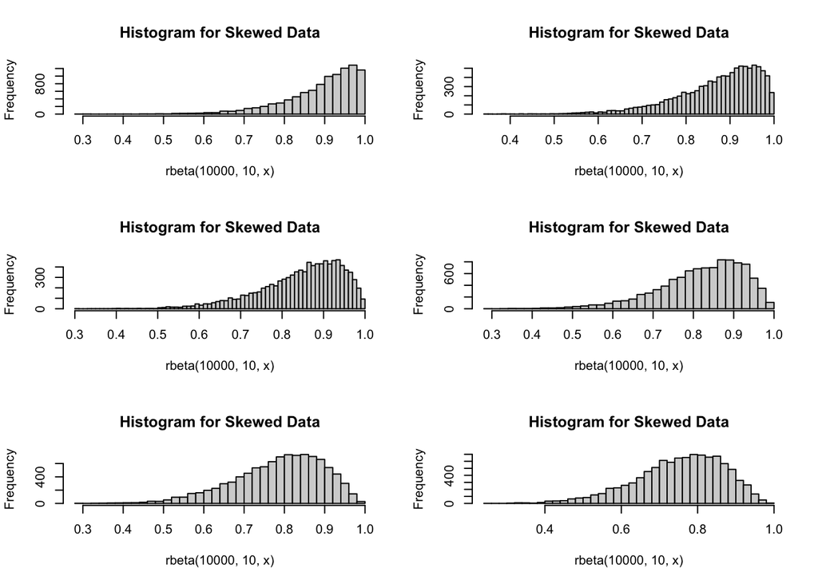

```
##          [,1]                  [,2]                  [,3]
## breaks   numeric,37            numeric,67            numeric,71
## counts   integer,36            integer,66            integer,70
## density  numeric,36            numeric,66            numeric,70
## mids     numeric,36            numeric,66            numeric,70
## xname    "rbeta(10000, 10, x)" "rbeta(10000, 10, x)" "rbeta(10000, 10, x)"
## equidist TRUE                  TRUE                  TRUE
##          [,4]                  [,5]                  [,6]
## breaks   numeric,37            numeric,37            numeric,39
## counts   integer,36            integer,36            integer,38
## density  numeric,36            numeric,36            numeric,38
## mids     numeric,36            numeric,36            numeric,38
## xname    "rbeta(10000, 10, x)" "rbeta(10000, 10, x)" "rbeta(10000, 10, x)"
## equidist TRUE                  TRUE                  TRUE
```

```r
par(mfrow = c(3,2))

sapply(exp(seq(0.2, 1.2, 0.2)), function(x){ #Using a custom function six times
  hist(rbeta(10000, #Call histogram for random numbers drawn from beta distribution of 10000 numbers
             10, #Setting shape values
             x), #Setting shape values
       breaks = 50, #Breaks for histogram
       main = paste0("Histogram for Skewed Data")) #Title for plots
})
```

```r
par(mfrow = c(1,1))
```

If we shrink our stable shape value to less than one, we approach exponential distributions and we don’t approach normalcy as the values become even.

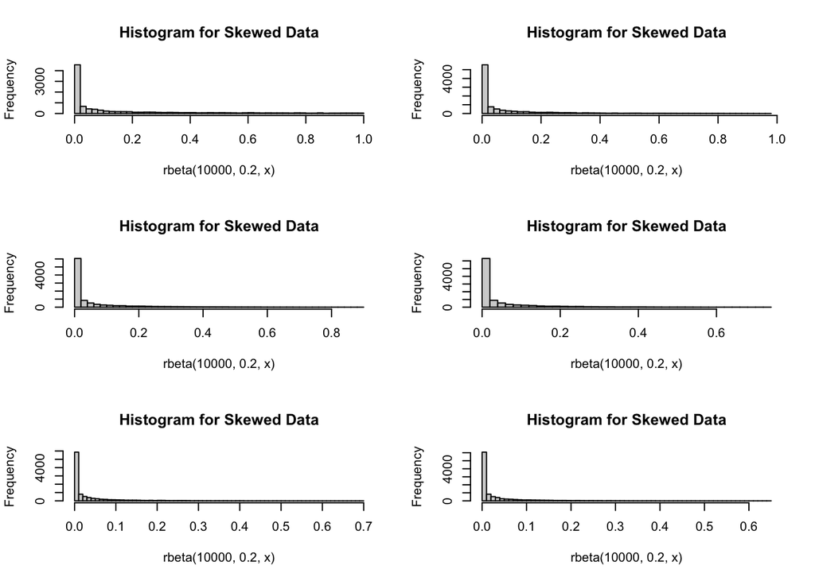

```
##          [,1]                   [,2]                   [,3]
## breaks   numeric,51             numeric,50             numeric,46
## counts   integer,50             integer,49             integer,45
## density  numeric,50             numeric,49             numeric,45
## mids     numeric,50             numeric,49             numeric,45
## xname    "rbeta(10000, 0.2, x)" "rbeta(10000, 0.2, x)" "rbeta(10000, 0.2, x)"
## equidist TRUE                   TRUE                   TRUE
##          [,4]                   [,5]                   [,6]
## breaks   numeric,38             numeric,71             numeric,66
## counts   integer,37             integer,70             integer,65
## density  numeric,37             numeric,70             numeric,65
## mids     numeric,37             numeric,70             numeric,65
## xname    "rbeta(10000, 0.2, x)" "rbeta(10000, 0.2, x)" "rbeta(10000, 0.2, x)"
## equidist TRUE                   TRUE                   TRUE
```

```r
par(mfrow = c(3,2))

sapply(1:6, function(x){ #Using a custom function six times
  hist(rbeta(10000, #Call histogram for random numbers drawn from beta distribution of 10000 numbers
             0.2, #Setting shape values
             x), #Setting shape values
       breaks = 50, #Breaks for histogram
       main = paste0("Histogram for Skewed Data")) #Title for plots
})
```

```r
par(mfrow = c(1,1))
```

Being able to manipulate distributions in this way can help us add specific parameters for some of our expectations for how production and preservation may bias our estimates of past community composition and rates of past ecological change. Let’s look at our basic statistics again, using skewed distributions. We will build four vectors with 1000 random values drawn from four different distributions.

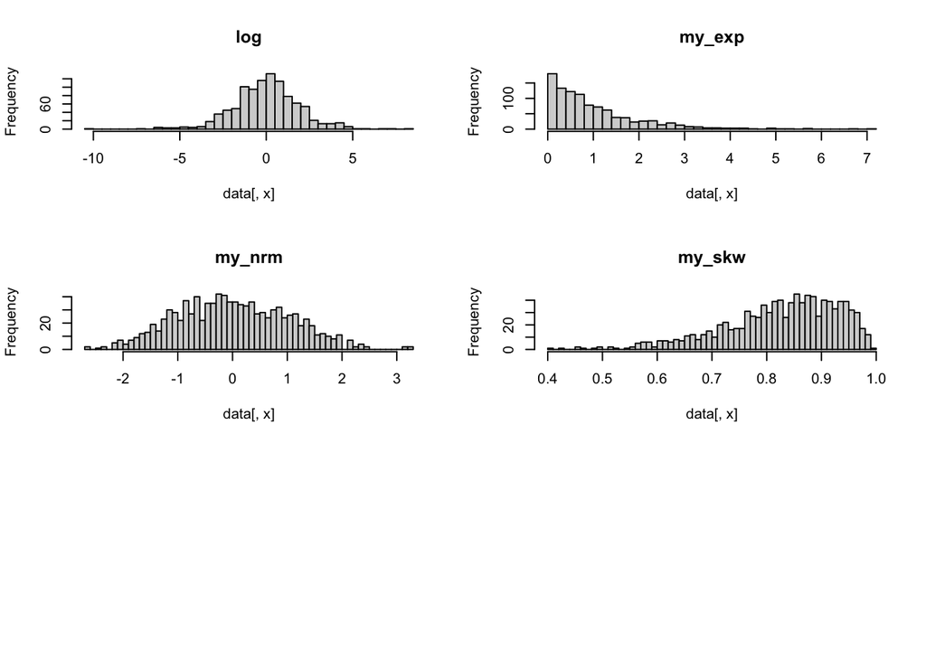

```r
my_log <- rlogis(1000)
my_exp <- rexp(1000)
my_nrm <- rnorm(1000)
my_skw <- rbeta(1000, 10, 2)

my_dist <- data.frame(log = my_log, my_exp, my_nrm, my_skw)

my_hist <- function(x, data){
  hist(data[,x], breaks = 50, main = colnames(data)[x])
}

par(mfrow = c(3,2))

invisible(lapply(1:ncol(my_dist), my_hist, data = my_dist))

par(mfrow = c(1,1))
```

We encounter a problem with the above - the ranges of the numbers are rather different, and the “rlogis()” function is giving us an exponential relationship between the mean and the min/max, but it is still more or less normally distributed.

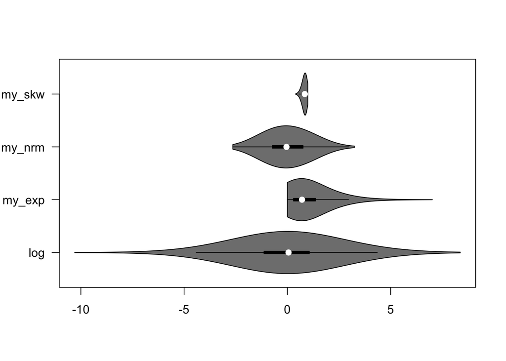

```r
vioplot::vioplot(my_dist, horizontal = TRUE, las = 1)
```

We need to scale these results from 0 - 1 and we can treat them all as probabilities. We divide each by their max value and, in the case of the log values, we do this with the absolute value (giving us a one-tailed log distribution).

```r
prob_dist <- data.frame(log = abs(my_log)/max(abs(my_log)), #We take absolute value and divide by max
                        exponential = my_exp/max(my_exp), #We divide by the max value
                        normal =  (my_nrm + abs(min(my_nrm)))/(max(my_nrm + abs(min(my_nrm)))),  #Add the minimum (to get to 0), then divide by the new maximum.
                        right_skew = my_skw) #Beta-generated distributions are prob. distributions!
```

Now we can have a look at all of these more or less side by side, let’s use vioplot to see more details about the shape of our new probability distributions.

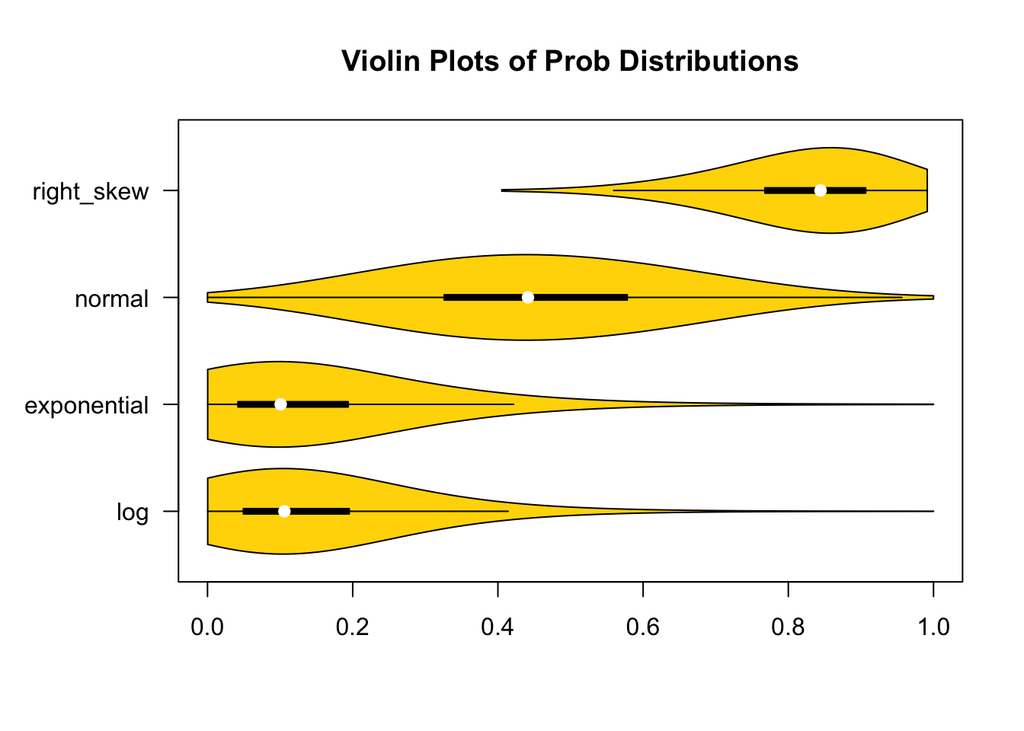

```r
par(mar = c(5, 6, 4, 2) + 0.1)

vioplot::vioplot(prob_dist,
                 horizontal = TRUE,
                 col = "gold",
                 las = 1,
                 main = "Violin Plots of Prob Distributions")
```

```r
par(mar = c(5, 4, 4, 2) + 0.1)
```

### 6. Using Probability Distributions to Control Sampling

We can use these kinds of parameters to determine the probability that a sample is drawn from a group. Let’s work with some basic sampling to understand what we’re talking about here.

The R function “sample()” lets us draw a number of samples from a given vector of data. Arguments for this function include “size =”, “replace =”, and “prob =”.

Let’s try a simple example.

```r
my_pop = c("A", "B", "C", "D", "E", "F", "G", "H", "I", "J")

my_spl = sample(my_pop, size = 5)
```

If you call “my_spl”, you will get a different result than me, because these are randomized samples with no probability (thus, equal probability of each choice). This is a good time to see what happens when sampling with or without replacement.

```r
my_spl = sample(my_pop,
                size = 10,
                replace = FALSE)

my_spl[order(my_spl)]
```

```
##  [1] "A" "B" "C" "D" "E" "F" "G" "H" "I" "J"
```

You’ll see that we all do get the same answers at this point. Our sample is equal to the population.

When sampling with replacement, we can make sample populations larger than the number of things that we’re drawing from. This reasonably simulates identifying a fossil from a sedimentary population - there’s only so many things that can be encountered, and we will count them based on given probabilities assigned to each group.

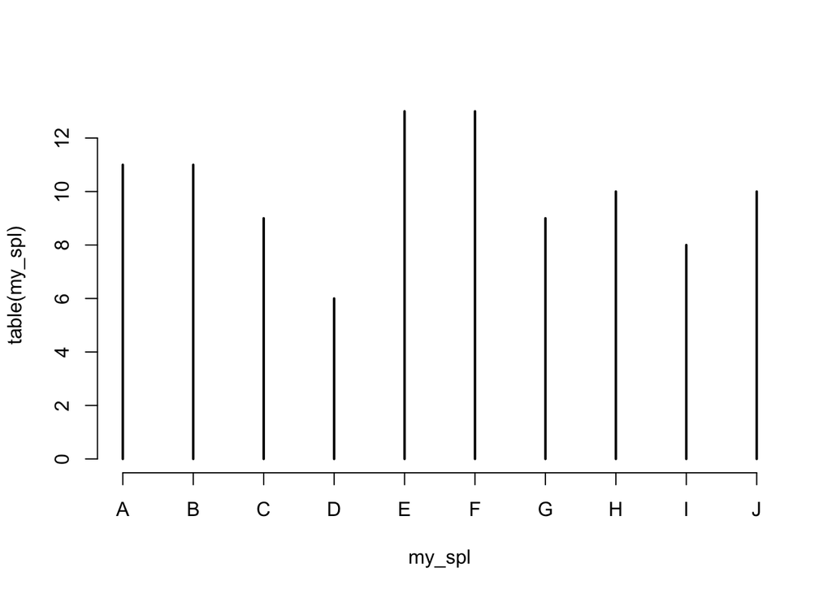

```r
my_spl = sample(my_pop,
                size = 100,
                replace = TRUE)

spl_cnt = table(my_spl)

plot(table(my_spl))
```

Let’s up the sample size and see if the frequency distributions evens out.

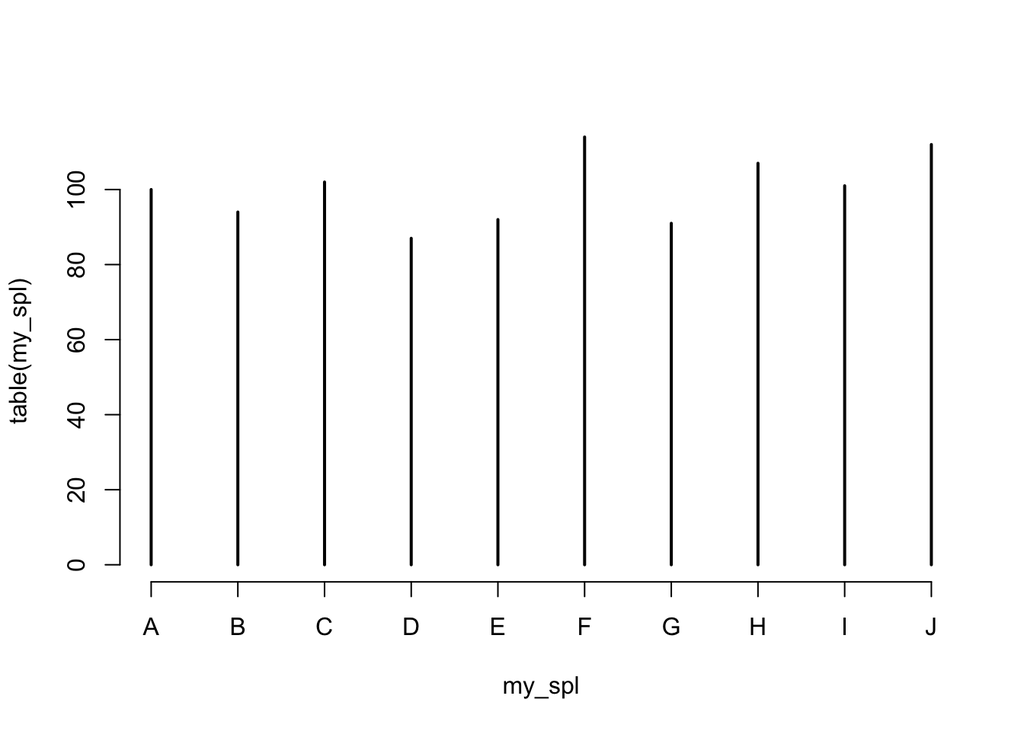

```r
my_spl = sample(my_pop,
                size = 1000,
                replace = TRUE)

spl_cnt = table(my_spl)

plot(table(my_spl))
```

Now let’s modify our probability.

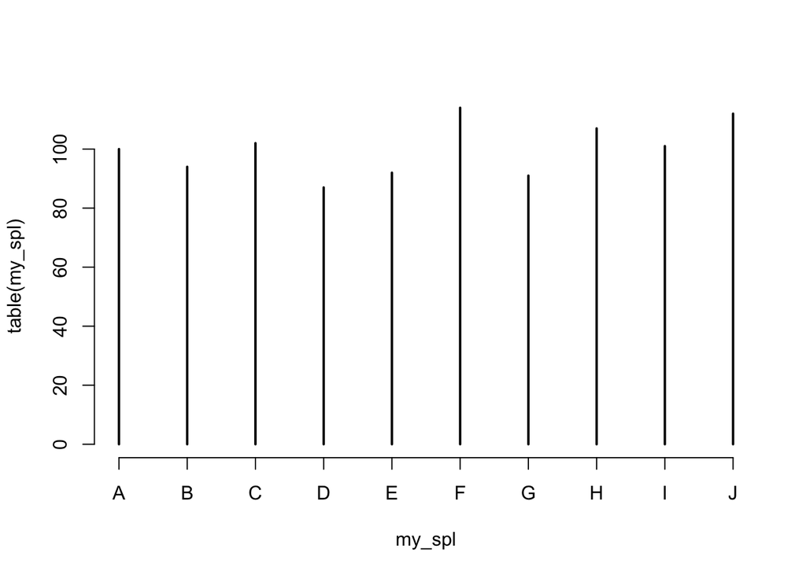

```r
plot(table(my_spl))
```

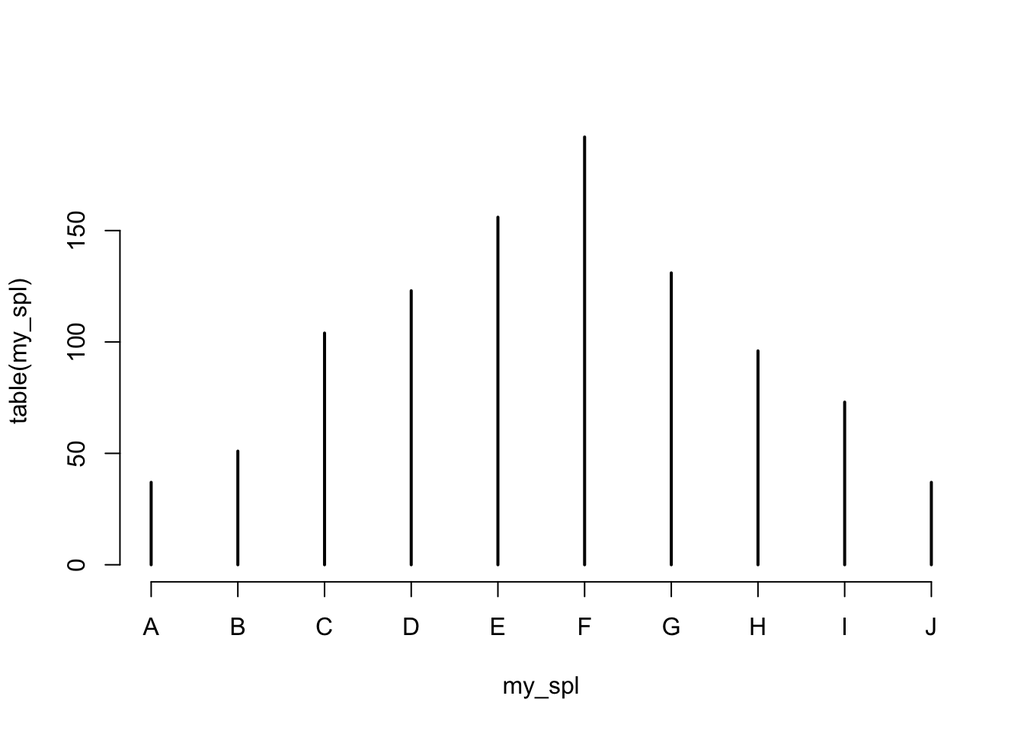

```r
my_spl = sample(my_pop,
                size = 1000,
                replace = TRUE,
                prob = c(seq(0.2,0.8,0.2),1,1,seq(0.8,0.2,-0.2)))

plot(table(my_spl))
```